# Chapter 2: Counting Words in the 19th-Century British Parliamentary Debates

Our introduction to text mining begins with tracking words’ context by processing data, counting words, and visualizing the words that co-occur with one-another. As the linguist John Rupert Firth said, “You shall know a word by the company it keeps.”<sup>1</sup> Tracking subtle variations in the context with which different words are used helps historians and other analysts to understand the cultural biases that structure our collective thinking. They may help us to understand how a culture understands men and women differently, how a culture describes people of different nationalities, the difference between a concept like “the foreign” and its near synonyms like “outsider” that nevertheless are used in important and different ways, or how these concepts are changing over time. In the course of this book, we will offer a taste of the subtle and refined approaches that analysts have used to unpack the context of different words.  
Understanding the historical context of language begins with how we interpret and approach individual words. In this chapter, we treat the words we process as “keywords”–terms that are central to understanding culture and society, but whose meanings are often contested or have shifted over time.<sup>2</sup> For example, the word “labour” may be a particularly interesting word to an analyst of 19th-century Britain, more so than the word “table.” This is because in the 19th-century debates, the meaning of the word “labour” evolved alongside industrialization, class conflict, and political reform. Early in the century, labour was often used in economic terms, referring to the input of human work in production, as discussed by political economists like Adam Smith. But as the century progressed—and especially with the rise of trade unions, Chartism, and later the Labour movement—the term labour took on a more political and moral dimension. It began to signify not just work, but the working class itself, with connotations of exploitation, rights, and collective struggle. The meaning of the word “table” on the other hand, is generally stable, literal, and uncontroversial. It refers to a physical object–typically a piece of furniture–and does not carry the kind of cultural significance that keywords do.

Recognizing words as evolving and changing–rather than fixed–allows us to glean greater insight into how language reflects broader cultural transformations. It invites us not to take words at face value, but to remember that language is dynamic and often shaped by power struggles, and that the way we process data impacts our subsequent analyses of these power struggles.

The data processing techniques we foreground will lead to our first visualization, where we transform individual utterances or debates into high-level visualizations depicting the frequencies of keywords and their associations.<sup>3</sup> To achieve this end, we will introduce three basic techniques for processing text. We will: a) access data for the British parliamentary debates of the House of Lords and House of Commons, 1850-59 using the `hansardr` library, b) filter a relevant decade for keywords of interest, and c) count the words that appear in the same context as our keywords in order to study the associations of the keywords in more detail.<sup>4</sup>

One common way to study a word’s context is through collocate analysis—the identification of words that frequently appear near a given keyword within a specified textual window. These neighboring words, or collocates, provide clues about how a term is used, what associations cluster around it, and how its meaning may shift across time or social settings. For historians, collocates can help reveal implicit assumptions embedded in language: whether a group is discussed in economic, moral, or political terms; whether a concept is framed positively or negatively; or how competing synonyms develop distinct connotations. At the same time, collocates offer only a partial view of meaning. They highlight patterns of association, but they do not by themselves show how words function within sentences or arguments. For that reason, researchers often pair collocate analysis with concordance-style approaches such as Keywords in Context (KWIC), which allow closer inspection of usage in specific passages.

Each of the techniques presented in this chapter have both promise and limits. As our companion volume, *The Dangerous Art of Text Mining*, makes clear, simple word counts are almost never sufficient on their own to support an in-depth analysis of culture.<sup>5</sup> Before we count words, we need to decide which words are worth counting. Words are not neutral objects: they are historically conditioned artifacts, shaped by the institutions, conflicts, and assumptions of their time. In nineteenth-century Britain, Parliament was not primarily concerned with tables and chairs; it was actively debating gender, property, citizenship, and empire. Questions such as whether a woman could divorce her husband and retain control over her property, how foreigners and colonial subjects should be classified, or how passports and refugee protections ought to function were not peripheral—they were central to parliamentary business. As a result, the vocabulary of parliamentary debate reflects these struggles. The words we choose to examine in this chapter are therefore guided not only by computational convenience, but by historical judgment: we attend to terms associated with gender, class, nationality, and empire because these concepts structured the problems Parliament was trying to solve. Word counting, in this sense, is not a purely technical exercise; it is an entry point into historically situated questions about power, governance, and social change.

## Loading the Hansard Data

First we will load the data we wish to analyze. Analysts, programmers, researchers, and the like routinely import software packages developed by others to expand the range of tools available to them.

The authors developed a data package to go with this book, `hansardr`, to give readers an ability to access the Hansard 19th-Century British Parliamentary Debates within the R environment.<sup>6</sup> This is a cleaned, analysis-ready corpus of the 19th-century British Parliamentary Debates (1803-1899), also known as “Hansard” in reference to Thomas Curzon Hansard, the publisher. It identifies debates whose records are missing from UK Parliament’s corpus, and it also offers a field for disambiguated speakers. We believe this dataset will enable researchers to analyze the Hansard debates, including speaker discourse, in a way that has not been accessible before. Once installed, the data can be loaded with the `data()` function.

R also has a large ecosystem of libraries—which are bundles of additional functions, example data, and notes created by the wider R community. Think of libraries as add-ons that expand what R can do. If base R is the core toolkit, libraries contain all the specialty tools others have built for tasks like text analysis, mapping, visualization, or cleaning messy historical data.

To load these specialty tools, we use `library()`, like this. Loading only works after the package has been installed—something we walk through in the “Computer Specifications and Setup” section.

We also placed a hashtag (`#`) followed by text; in R, this indicates a comment, meaning that we included text for explanation that is ignored when the code runs. We use comments to describe what the code does, explain why we made certain choices, or leave notes for our future selves. Here, we included a comment noting that this line of code loads the `hansardr` data package into the R session so its data is ready for use.

```r
# Load hansardr for accessing the Hansard debates
library(hansardr)
```

`hansardr` is now ready for use. It is conventional to load the software packages that will be use at the beginning of each new session. However, for the sake of demonstrating computational historical thinking, we will regularly load packages throughout a chapter so the reader can more easily see which functions relate back to different packages.

When working with functions in R, it is important to remember that code must be run in order, because each step often depends on what came before it. For example, if we plan to use a package such as `hansardr`, we must first load it with `library(hansardr)` before calling any of its functions. If we skip this step, R will not know where the `hansardr` functions come from and will return an error such as “could not find function,” even if the code is correct. Similar errors can also occur when data is not processed in the proper sequence, since later steps may rely on datasets or data transformations that have not yet been created.

## Navigating the `hansardr` Data

To make working with the Hansard corpus quicker and easier–and to prevent our personal computers from being overloaded with too much data at once–we partitioned the century long corpus into decade sections. In the field of data analysis, it is common to call these sections “subsets.”

The first subset we will meet is a collection of the speeches of parliament, 1850-59, broken into sentences, where each row of the data frame is one sentence. Later, we will meet more datasets that contain “metadata,” or information about the speaker, year and date of the speech, and other important contextual information for historical analysis.

The `hansardr` corpus is subsetted by decade. As shown by Table 1, each decade has four types of data, labeled: `hansard`, `debate_metadata`, `speaker_metadata`, and `file_metadata`. In the following table, “YYYY” stands in for any given decade.

Overview of the hansardr corpus, showing the primary text files and their associated metadata. Each data set is linked through a common sentence ID.

| Label | Description | Key |
| --- | --- | --- |
| hansard_YYYY | Hansard debate text | sentence_id |
| debate_metadata_YYYY | Metadata such as speech date and title. | sentence_id |
| speaker_metadata_YYYY | Metadata on speakers. | sentence_id |
| file_metadata_YYYY | Metadata for source file, column, and more. | sentence_id |

Both text and metadata are divided into subsets named by decade, for instance, `hansard_1850`. `hansard_1850` contains just the speech text as well as a unique sentence ID that can be used to connect the speech text with its corresponding metadata. We will demonstrate this process later in *Text Mining for Historical Analysis*.

Processing both text and dates is important for historical analysis. In this chapter, we will start working exclusively with text–not dates–because they are easy to process when counting words. But the other subsets within `hansardr` contain other data types.

We can use `data()` to load one of these decade-based subsets of the Hansard corpus.

```r
# Load the Hansard debate text for 1850
data("hansard_1850")
```

A new variable named `hansard_1850` is now able to be seen in our Global Environment panel. If you are using RStudio, you can explore the data by clicking on its name in the Global Environment pane (the top right quadrant of RStudio). Clicking on the name of the dataset will open a new tab containing a view of the data, which can be searched for a keyword, like in a spreadsheet. One can also double-click on any row in the data frame to select a row, then copy that data and paste it into a Word Document or other tool.

The Hansard subsets are purposefully small enough to open and explore on a personal computer. When working with larger datasets, it may not be possible to open the entire dataset in another tab. Instead, in the Global Environment Panel you can also click on the blue “>” symbol to the left of each data frame to display the “fields” by which the dataset is structured, in this case, the names of the columns in the dataset, as well as a preview of the content of each of these columns.

In addition to exploring the data in RStudio, there are a few functions that provide the means to look at sections of the dataset in greater detail. Throughout this book, we will routinely “inspect” the data by using functions like `head()` to see how the data is transformed at different processing steps. Getting into the habit of using functions like `head()` makes it easier to notice and interrogate problems as they arise, or ensure that the data transformations meet expectations. At the console, an analyst can also use `head()` to ask R to display the first six rows of the data. In some versions of RStudio you will see an arrow that allows you to move between two columns.

As shown by Table 2, the first column in this dataset is `sentence_id`, which gives a unique identifier for each sentence, including information about which series of parliamentary proceedings we are looking at, which volume and page, and which sentence number on each page. The second column is `text`. Each row is a distinct sentence of text. These speeches were broken into sentences during the dataset creation stage, where the authors wrote a script to detect punctuation and line breaks.

Below is an excerpt from `hansardr`:

```r
# Keep the first rows of the Hansard dataset
# - slice_head() selects the first five rows
first_five_rows <- hansard_1850 %>%
  slice_head(n = 5)

# View the selected rows as a formatted table
# - kable() formats the data as a table
kable(first_five_rows,
      caption = "Excerpt from the 1850 Hansard corpus showing
                 sentence-level text with associated sentence ID values.") # Add a table caption
```

Excerpt from the 1850 Hansard corpus showing sentence-level text with associated sentence ID values.

| sentence_id | text |
| --- | --- |
| S3V0108P0_0 | , which had been prorogued successively from the 1st of August to the 9th of October, from thence to the 20th of November, thence to the 16th of January, and from thence to the 31st January, met this … |
| S3V0108P0_1 | The Parliament was opened by Commission, the LORDS COMMISSIONERS present being the LORD CHANCELLOR; the LORD PRESIDENT OF THE COUNCIL (the Marquess of Lansdowne); the LORD PRIVY SEAL (the Earl of Mint… |
| S3V0108P0_2 | called attention to a great omission of their duty on the part of Ministers, with respect to the privileges of their Lordships, which might and ought to have been avoided. |
| S3V0108P0_3 | At pre-sent there were two vacancies in the representative Peers of Scotland, in consequence of the deaths of the Earl of Airlie and of Lord Colville. |
| S3V0108P0_4 | Although the Act of Parliament directed that the proclamation should issue forthwith for the election of representative Peers to fill up any vacancies which might occur, by death or otherwise, no such… |

To display the data in a more visually appealing format, we can use the `knitr` package, which provides the `kable()` function for creating clean, basic tables from R objects. We then enhance these tables with the `kableExtra` package, which adds styling options—such as custom column widths, captions, alignment, and shading—allowing us to produce polished, publication-quality tables.

## Tidy Text Mining and Loading Libraries

Most of the functions used in the first chapters of this book come from a software package called `tidyverse` which is a family of smaller packages developed by Chief Scientist at Posit (formerly known as RStudio), Hadley Wickham. The `tidyverse` was created to order data in “tidy” tables where it is structured as a data frame made up of columns and rows. In other words, the `tidyverse` is built to work with data like `hansard_1850`.<sup>7</sup>

We have found that a tidy approach to text exploration and analysis allows us to write code quickly and effectively, giving us ample control over the data and allowing us to inspect the output of every data processing step and type of analysis. This library thus supports analysts focusing on questions about data processing and history without being weighed down by the nuances of different structural and syntactic coding problems.

We distinguish between writing code and processing data, proposing that data processing and historical analysis are co-creative practices. Data processing shapes how we interpret the past—it is not a neutral task, but one that governs the possibilities of historical understanding. At the same time, the historical material we study–the observations we make–might inform and reshape our data processing methods. We will return to this central idea of “computational historical thinking”–which we introduce in our introduction–throughout the book, as we demonstrate how iterative adjustments to our processing approach impact our analysis.

In this chapter we will also use the `tidytext` library, developed by David Robinson and Julia Silge, to work with textual data.<sup>8</sup> The `tidytext` library contains a variety of tools useful for processing text and treating text as data. Many sections in this book will therefore begin by loading the two libraries `tidyverse` and `tidytext`.

```r
# Load the tidyverse and tidytext libraries
library(tidyverse)
library(tidytext)
```

To count words in Hansard, we will use the `unnest_tokens()` function from `tidytext`. While there are many ways to count words over time, one way to do this–that is also very human readable–is to put our data into a format where each word of the text is on a separate row. These individual words are called “tokens.” The process of splitting chunks of text into individual units is called “tokenization.” While singular words are often called “tokens,” a common term used to instead describe multi-word phrases is “n-gram” (such as using the term “bigrams” to describe sequential, two-word phrases).

In this one-token-per-row format we can easily process our data. This approach to data processing is common in the humanities and handles text using the “Bags of Words” (BoW) approach, where text data is treated as a collection (or “bag”) of individual words without regard to grammar, order, or context.<sup>9</sup> The focus is instead on word frequency or occurrence.

```r
# tokenize the "text" column of the hansard_1850 dataset into one word per row
# - unnest_tokens() from the tidytext package splits text into lowercase words
# - The new column will be called "word"
tokenized_hansard <- hansard_1850 %>% # Create a new data frame named tokenized_hansard
  unnest_tokens(word, text) # Tokenize the text column of hansard_1850
```

The above code also has new symbols, called “operators.” Operators are essential for data processing. Throughout the course of this book we will introduce multiple different kinds of operators.

The assignment operator, `<-`, sometimes translated as “gets,” points to the output of a function and is followed by the name of an original dataset. The `%>%` operator, called a “pipe,” and translated as “next,” is used to chain together successive transformations of a dataset. We will continue to use operators for data processing throughout the book, and they will begin to make more sense when we cover more examples.

If this is your first time using a programming language for analysis, it can be useful to practice reading each line of code as a sentence of instructions that tells the computer what output to make, what input to use, and what processes to go through in a certain order. We sometimes suggest that first time programmers translate code into a series of English sentences, using their knowledge of the `<-` and `%>%` operators, the names of variables, and their understanding of distinct commands. The code above be read as follows: “Create a new variable called `tokenized_hansard`. Start with the dataset `hansard_1850`. Next, unnest the tokens in the”text” column of `hansard_1850`, unpacking those strings of text into individual words.”

One may also notice the arguments passed to `unnest_tokens()`, “word” and “text.” Functions like `unnest_tokens()` take a set number of arguments, typically in a precise order. The first argument is the type of unnesting that will be employed. The second argument is the name of the column from the original `hansard_1850` data that we will work on, in this case, “text.”

As you inspect the arguments of each function, consider the fact that those arguments exist because they allow the analyst to change the arguments to get different results. With the `unnest_tokens()` function, the analyst could hypothetically choose to “unnest” the sentences into tokens of different length, for instance, sentences, n-grams, or other units of text. In later chapters we will explore some of these capabilities of the `unnest_tokens()` function. Alternatively, if `unnest_tokens()` were being applied to a different dataset where the column had a different name than “text,” we could change the column name from “text” to something else. In later examples, we will use the same commands applied to different datasets with different column names. For now, we will mainly use `unnest_tokens()` with the arguments “word” and “text.”

Next, let’s inspect the results of our unnesting using `head()`, which returns just the first rows of a data frame.

```r
# Show the first six rows of the tokenized data
head(tokenized_hansard)
```

```
## # A tibble: 6 × 2
##   sentence_id word
##   <chr>       <chr>
## 1 S3V0108P0_0 which
## 2 S3V0108P0_0 had
## 3 S3V0108P0_0 been
## 4 S3V0108P0_0 prorogued
## 5 S3V0108P0_0 successively
## 6 S3V0108P0_0 from
```

However, we have a preference for looking at more data since that can give us a fuller picture of the data.

```r
# Show the first fifteen rows of our tokenized data
head(tokenized_hansard, n=15)
```

```
## # A tibble: 15 × 2
##    sentence_id word
##    <chr>       <chr>
##  1 S3V0108P0_0 which
##  2 S3V0108P0_0 had
##  3 S3V0108P0_0 been
##  4 S3V0108P0_0 prorogued
##  5 S3V0108P0_0 successively
##  6 S3V0108P0_0 from
##  7 S3V0108P0_0 the
##  8 S3V0108P0_0 1st
##  9 S3V0108P0_0 of
## 10 S3V0108P0_0 august
## 11 S3V0108P0_0 to
## 12 S3V0108P0_0 the
## 13 S3V0108P0_0 9th
## 14 S3V0108P0_0 of
## 15 S3V0108P0_0 october
```

`unnest_tokens()` did a lot of heavy lifting for us!

As part of our data transformation, the output data has a column named “word” for each individual token of the corpus. Notice that the words in `tokenized_hansard` look just like the words in the first sentence of the first speech in `hansard_1850`. Those speeches have been split into individual words, but the words are still in the same order. Notice that the command `unnest_tokens()` has also transformed all the words to lower-case and removed punctuation marks such as commas and periods. This transformation, often called “data cleaning” will make the words easier to count because the computer will not treat words differently based on capitalization or the presence of symbols.

As we inspect the results of unnesting, one might note that the input to `unnest_tokens()` was “tidy” in format – that is, it had two columns, one for “sentence_id” and one for “text”. After working with `unnest_tokens()`, the resulting output, `tokenized_hansard`, also is “tidy” in format. That is, it has two columns, one for `sentence_id` and one for `word`. This tidy format is both easily human readable and also easy to process and count.

## Lowercasing and Stripping Punctuation

While `unnest_tokens()` automatically converted all tokens to lowercase and removed punctuation for us, there may be situations where we want to perform these steps ourselves—for example, when processing text before tokenization or when applying our own custom cleaning rules. Lowercasing our words ensures they are not treated differently by the computer because of capitalization (e.g., Parliament vs. parliament), and removing punctuation prevents symbols such as commas or periods from being counted as part of a word.

These preprocessing steps help to standardize the corpus, making subsequent analysis—such as counting words—more consistent. FFor example, in `hansard_1850`, sentences often include commas and periods attached to words, and the same word may appear with different capitalization. Both punctuation and case variation can impact our analysis unless punctuation is removed and capitalization is standardized.

```r
# Display the first six sentences and their sentence IDs
# - head() keeps the first six rows
# - select() keeps only the sentence ID and text columns
# - kable() formats the results as a table
hansard_1850 %>%
  head() %>% # Keep the first six rows
  select(sentence_id, text) %>% # Keep the sentence IDs and text
  kable() # Format the results as a table
```

| sentence_id | text |
| --- | --- |
| S3V0108P0_0 | , which had been prorogued successively from the 1st of August to the 9th of October, from thence to the 20th of November, thence to the 16th of January, and from thence to the 31st January, met this … |
| S3V0108P0_1 | The Parliament was opened by Commission, the LORDS COMMISSIONERS present being the LORD CHANCELLOR; the LORD PRESIDENT OF THE COUNCIL (the Marquess of Lansdowne); the LORD PRIVY SEAL (the Earl of Mint… |
| S3V0108P0_2 | called attention to a great omission of their duty on the part of Ministers, with respect to the privileges of their Lordships, which might and ought to have been avoided. |
| S3V0108P0_3 | At pre-sent there were two vacancies in the representative Peers of Scotland, in consequence of the deaths of the Earl of Airlie and of Lord Colville. |
| S3V0108P0_4 | Although the Act of Parliament directed that the proclamation should issue forthwith for the election of representative Peers to fill up any vacancies which might occur, by death or otherwise, no such… |
| S3V0108P0_5 | The Peerage of Scotland was not therefore represented in Parliament at present as it ought to be. |

Now we can transform the text to lowercase and strip punctuation.

```r
# mutate() modifies variables in a dataframe, or creates new ones
# str_to_lower() transforms text to lowercase
# str_remove_all() removes all matches of a pattern (here, punctuation) from text
hansard_1850_clean <- hansard_1850 %>%
  mutate(text = str_to_lower(text), # Lowercase
         text = str_remove_all(text, "[[:punct:]]")) # Strip punctuation
```

```r
# Display the first six cleaned sentences and their sentence IDs
# - head() keeps the first six rows
# - select() keeps only the sentence ID and text columns
# - kable() formats the results as a table
hansard_1850_clean %>%
  head() %>% # Keep the first six rows
  select(sentence_id, text) %>% # Keep the sentence IDs and cleaned text
  kable() # Format the results as a table
```

| sentence_id | text |
| --- | --- |
| S3V0108P0_0 | which had been prorogued successively from the 1st of august to the 9th of october from thence to the 20th of november thence to the 16th of january and from thence to the 31st january met this day fo… |
| S3V0108P0_1 | the parliament was opened by commission the lords commissioners present being the lord chancellor the lord president of the council the marquess of lansdowne the lord privy seal the earl of minto the … |
| S3V0108P0_2 | called attention to a great omission of their duty on the part of ministers with respect to the privileges of their lordships which might and ought to have been avoided |
| S3V0108P0_3 | at present there were two vacancies in the representative peers of scotland in consequence of the deaths of the earl of airlie and of lord colville |
| S3V0108P0_4 | although the act of parliament directed that the proclamation should issue forthwith for the election of representative peers to fill up any vacancies which might occur by death or otherwise no such p… |
| S3V0108P0_5 | the peerage of scotland was not therefore represented in parliament at present as it ought to be |

While the cleaning performed by `unnest_tokens()` or `str_to_lower` are important, they can also be deceptive. For instance, if we are interested in how many times speakers refer to the Bank of England (capital B, capital E), we do not want all text lowercased because we want to be able to look for instances of “the Bank” with capitalization preserved.

## Counting Words

Now we are going to bring together what we have learned by chaining together multiple functions that will be used to process the Hansard data.

The `count()` function from the `tidyverse` groups like tokens with like tokens, then counts them. Below, we are passing `count()` one argument, the name of the column to operate on–in this case, “word” from the tokenized hansard data.

```r
# Count each unique word
# - count() counts the occurrences of each word
# - arrange() sorts the words from most to fewest occurrences
tokenized_hansard_counts <- tokenized_hansard %>% # Start with the tokenized data
  count(word) %>% # Count the occurrences of each word
  arrange(desc(n)) # Sort from most to fewest occurrences

# View the first six rows of the word counts
head(tokenized_hansard_counts)
```

```
## # A tibble: 6 × 2
##   word        n
##   <chr>   <int>
## 1 the   2588864
## 2 of    1404831
## 3 to    1126226
## 4 that   726686
## 5 and    706117
## 6 in     597753
```

With the command `arrange(desc(n))`, we tell the computer to arrange the results from greatest to least. We perform this step so that the results are easier to read, not because this step is necessary for counting words.

We now have a frequency count of every word recorded in the speeches of Hansard, 1850-59. The initial results are unimpressive. In our dataset, as with most textual datasets, the most common words are also often the least interesting. For this reason, analysts compile lists of the most common words, called “stop words.” Analysts often remove stop words from their results before analysis.

The `tidytext` package comes with a prepared list of stop words. We can remove them from our results by loading the “stop_words” dataset and then passing the dataset as an argument to the `anti_join()` function. `anti_join()` keeps all the rows in the first dataset that do not have a match in the second dataset. Using `anti_join()` we can remove words we do not want in our analysis from our data.

```r
# Load the tidytext dataset of common stop words
data("stop_words")

# Remove common stop words from the word counts
# - anti_join() removes words found in the stop_words dataset
stopworded_hansard_counts <- tokenized_hansard_counts %>% # Start with the word counts
  anti_join(stop_words) # Remove common stop words

# Display the first six rows of Hansard word counts with stop words removed
head(stopworded_hansard_counts)
```

```
## # A tibble: 6 × 2
##   word            n
##   <chr>       <int>
## 1 hon        125465
## 2 house      118861
## 3 government  95417
## 4 bill        77322
## 5 noble       73180
## 6 lord        68942
```

These results cleaned of their stop words seem sensible for parliament. Some of them demonstrate the way that members of parliamentarians refer to each other, for example, as “my noble lord” or “the hon[ourable] member [in question].” Speakers in parliament also routinely refer to the business of parliament, especially referencing the “house [of commons or lords],” the “bill” or “question” under debate, the state of the “country,” and how much “time” is available for debate.

General words, of course, give us little insight into the business of parliament. Later sections will give us richer tools for examining how the content of speeches changed over time. For now, we have successfully achieved the first step of analysis, the processing of text into words, and the counting of words.

## Searching for Keywords

```r
# Find the word "india" in the word count table
# - filter() keeps only rows where the word is "india"
# - without assigning the result with "<-," R displays the output
stopworded_hansard_counts %>%
  filter(word == "india") # Keep only the word "india"
```

```
## # A tibble: 1 × 2
##   word      n
##   <chr> <int>
## 1 india 20816
```

In this code, we pass `filter()` two arguments: first, the name of the column we will search for (“word”), and second the name to match (“india”). Here we are using the `==` operator to indicate we want to return an exact match, as opposed to returning words that might contain the word “india” such as “indian”.

We can do the same for any other keyword of interest.

```r
# Now filter the word column for "france"
stopworded_hansard_counts %>%
  filter(word == "france")
```

```
## # A tibble: 1 × 2
##   word       n
##   <chr>  <int>
## 1 france  7146
```

```r
# Now filter the word column for "jamaica"
stopworded_hansard_counts %>%
  filter(word == "jamaica")
```

```
## # A tibble: 1 × 2
##   word        n
##   <chr>   <int>
## 1 jamaica   475
```

Filtering for every word we wish to track, one-by-one, can be tedious and time consuming. Filter can also be used with other R operators, such as `%in%`, that save us time and energy by giving us the opportunity to cycle through multiple words of interest instead of just one.

To do this, we can first create our own custom list of words we wish to analyze.

```r
# Create a list of words commonly used to refer to women
# - c() combines the words into a single list
# - this list can be used to filter or search the corpus
identifiers_for_woman <- c("girl", "woman", "girls", "women", "wife", "wives", "widow",
                           "widows", "sister", "sisters", "female", "females",
                           "grandmother", "grandmothers", "aunt", "aunts")
```

Now we can use the `%in%` operator to check if a word from our list, `identifiers_for_woman`, is in the “word” column.

```r
# Keep only words that refer to women
# - %in% checks whether each word appears in the identifiers_for_woman list
# - filter() keeps only matching words
stopworded_hansard_counts %>%
  filter(word %in% identifiers_for_woman) # Keep words that refer to women
```

```
## # A tibble: 15 × 2
##    word            n
##    <chr>       <int>
##  1 wife         2222
##  2 sister       1153
##  3 woman        1063
##  4 women        1062
##  5 wives         479
##  6 widow         315
##  7 female        294
##  8 widows        254
##  9 sisters       240
## 10 females       195
## 11 girls         180
## 12 girl           76
## 13 aunt           62
## 14 grandmother    18
## 15 aunts          10
```

`filter()` is useful for more than just text data. It also works on quantitative data with comparison operators like the greater than, `>`, or less than, `<`, signs. This is handy if we want to filter for words that are said more or less than a specified number of times, as one example. For the sake of readability, we are only going to show the first 20 words that follow our filter.

```r
# Find words that appear fewer than 474 times
# - filter() keeps only words with counts below 474
# - slice_max() keeps the 20 most frequent of those words
stopworded_hansard_counts %>%
  filter(n < 474) %>% # Keep words that appear fewer than 474 times
  slice_max(order_by = n, n = 20) # Keep the 20 most frequent words
```

```
## # A tibble: 20 × 2
##    word           n
##    <chr>      <int>
##  1 contrast     473
##  2 pardon       473
##  3 thirteen     473
##  4 elizabeth    472
##  5 laboured     472
##  6 renew        472
##  7 seal         472
##  8 trustee      472
##  9 19           471
## 10 compare      471
## 11 concerns     471
## 12 denounced    471
## 13 mortality    471
## 14 publicly     471
## 15 silence      471
## 16 uttered      471
## 17 pride        470
## 18 sacrifices   470
## 19 acceptance   469
## 20 secrecy      469
```

We can also use multiple operators in conjunction with one-another. In the following code we do this by supplying the `&` operator to combine multiple conditions. The following example filters rows where n is greater than 474 and less than 476.

```r
# Find words that appear exactly 475 times
# - filter() keeps only words with counts between 474 and 476
# - slice_max() displays up to 20 matching words
stopworded_hansard_counts %>%
  filter(n > 474 & n < 476) %>% # Keep words that appear exactly 475 times
  slice_max(order_by = n, n = 20) # Display up to 20 matching words
```

```
## # A tibble: 6 × 2
##   word             n
##   <chr>        <int>
## 1 cities         475
## 2 depositors     475
## 3 jamaica        475
## 4 pause          475
## 5 shared         475
## 6 unfavourable   475
```

In just this quick glimpse of our data, meaningful words are beginning to appear. The word “Jamaica,” for example, appears along with the word “depositors.” These words hint at the political, economic, and social issues of the time, specifically the declining state of the economy. Members of Parliament discussed the slave revolt in Jamaica, including its scale and significance. Since the 17th century, Jamaica had its own parliament but was placed under martial law during the revolt. Its appearance here demonstrates that Jamaica was significant enough to command parliamentary attention, elevating the revolt to a major historical event that could not be ignored by Parliament.

## Tailoring our Word Count Analysis

Detecting and filtering for keywords of interest can be particularly meaningful for using data to tell history.

Our next function, `str_detect()`, treats data as patterns and detects their presence or absence. It returns `TRUE` if the pattern is detected, or `FALSE` if it is not. When a data type represents only two possible values, `TRUE` or `FALSE`, it is typically referred to as a “Boolean” value.

In the following example, we iterate through each word in the `identifiers_for_woman` list to check whether the value contains “girl.”

```r
# Check which words contain the text "girl"
# - str_detect() returns TRUE for words containing "girl"
identifiers_for_woman %>%
  str_detect("girl") # Test each word for the text "girl"
```

```
##  [1]  TRUE FALSE  TRUE FALSE FALSE FALSE FALSE FALSE FALSE FALSE FALSE FALSE
## [13] FALSE FALSE FALSE FALSE
```

The results from `str_detect()` are not very telling for analysis. Instead, for a textual analysis we often use both functions, `filter()` and `str_detect()`, together so that we return a more human-readable result.

The following example searches `hansard_1850` for the keyword “coal.” Notice that `str_detect()` is nested inside the command `filter()`. Together, these commands tell the computer to filter for only those rows of the column “text” that contain the keyword “coal.”

```r
# Keep speeches that mention the exact word "coal"
# - \\b matches a word boundary, so "coal" is matched as a whole word
# - str_detect() searches the text for the pattern
hansard_coal <- hansard_1850 %>% # Start with the Hansard data
  filter(str_detect(text, "\\bcoal\\b")) # Keep speeches containing the exact word "coal"
```

Something else interesting is happening in our code. The word “coal” has a funny looking set of characters, `\\b`, on either side. Together with the word “coal,” these special characters are make up part of a “regular expression” often abbreviated as “regex.” Regular expressions are sequences of characters that define search patterns, typically used for string matching, processing, and extraction.

One reason the `str_detect()` function is so special is because, unlike `filter()` by itself, the `str_detect()` function enables us to match with regular expressions, not just words. `\\b` indicates a word’s boundaries. It matches the position between a word character (e.g., letters, numbers) and a non-word character (e.g., space, punctuation, or the start/end of a string). `\\b` at the end ensures that “coal” is a standalone word, meaning it will match “coal” but not “coalesce” or “charcoal.”

The result of our search is variable, `hansard_coal`, that contains only sentences from the 1850 debates that contain the word “coal.”

```r
# Load knitr for creating fancy tables
library(knitr)

# Display the first six speeches that mention "coal"
# - head() keeps the first six rows
# - select() keeps only the text column
# - kable() formats the results as a table
hansard_coal %>%
  head() %>% # Keep the first six rows
  select(text) %>% # Keep only the text column
  kable() # Format the results as a table
```

| text |
| --- |
| The manufacturers of this country relied on their capital, and their command of coal and iron, for a continuance of their prosperity; but, again, let them cast their eyes on the other side of the Atla… |
| Mines, also, except coal, clay pits, slate quarries, and other descriptions even of real property escaped the operation of the Act. |
| One class of offences which was more particularly adverted to in this part of the Bill, was that of the offence of coal stealing. |
| A coal-owner told him that he was plundered of many tons of coal per week, owing to the difficulty of prosecuting the offenders. |
| They were subjected to great loss by the theft of small articles of coal, and they submitted from time to time to the injury rather than prosecute; till, at last, they found themselves compelled to pr… |
| Here, perhaps, is one county abounding in coal and stone—the latter advantageous for the construction of houses for all classes. |

## Finding and Comparing Keywords’ Context

Typically, we want to do more than simply search for a singular keyword. We may also want to search for collocates, or words that are “co-located” next to one-another. These words form the linguistic context of a given keyword.

We already have everything we need to make this happen: we can search for a keyword, we can break up text into words, and we can count the words. We can use our knowledge to search for the context of several keywords and compare them in visual form.

The following code chains multiple data processing steps together.

```r
# Tokenize and count words in the "text" column of the hansard_coal dataset
# - unnest_tokens() tokenizes the text into one word per row
# - anti_join() removes common stop words (e.g., "the", "and")
# - str_detect() identifies and removes tokens that contain digits (e.g., years, numbers)
# - count() counts the frequency of each remaining word
# - arrange() sorts the word counts in descending order for easier reading
coal_context <- hansard_coal %>% # Create a new data frame
  unnest_tokens(word, text) %>% # Tokenize the "text" column
  anti_join(stop_words) %>% # Remove stop words
  filter(!str_detect(word, "[:digit:]")) %>% # Remove tokens with digits
  count(word) %>% # Count word frequencies
  arrange(desc(n)) # Sort by frequency
```

Instead of running these functions independently, we have chosen to chain them together with the pipe, `%>%`, operator. Using the pipe allows us to use many functions sequentially without storing intermediary variables.

Notice the line of code that reads `filter(!str_detect(word, "[:digit:]"))`. `[:digit:]` is a regular expression in R that matches all digits, this way we do not have to specify them one-by-one. We added `!` to filter out any entries that comprise digits. The negation operator, `!`, tells R to do the opposite of what the function usually does. Using it in the `filter()` function and preceding `str_detect()`, we ask to return text, not digits like the dates recorded in Hansard.

```r
head(coal_context)
```

```
## # A tibble: 6 × 2
##   word           n
##   <chr>      <int>
## 1 coal         422
## 2 steam         50
## 3 duties        46
## 4 bill          42
## 5 government    40
## 6 mines         40
```

These are the words that appear most frequently with the word “coal.” When sharing our results, however, we may want to visualize our data instead of providing a table so we can analyze collocates more easily.

We can visualize just the top 20 words that co-occur with the word “coal” by selecting the `top_n(20)` appearances from our sorted data.

To visualize our data, we will use `ggplot`. `ggplot` is an R package used for creating visualizations. It follows an approach that allows users to build plots layer by layer, combining data, aesthetics (e.g., axes, colors), and geometric objects (e.g., points, lines) to create visualizations. We will use `ggplot` frequently throughout this book.

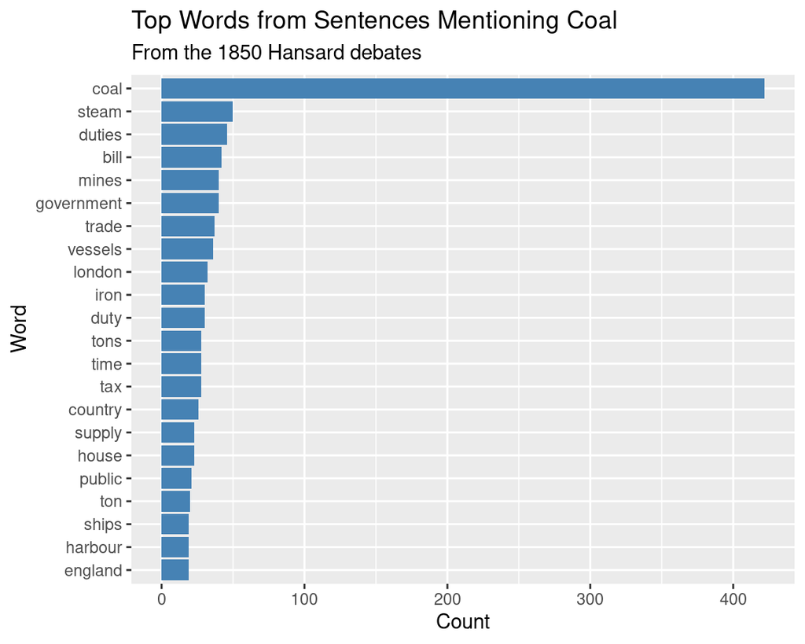

Top words in sentences mentioning coal (Hansard, 1850)

```r
# Keep the 20 most frequent words
# - top_n() selects the words with the highest counts
top_coal <- coal_context %>%
  top_n(20) # Keep the 20 most frequent words

# Visualize the most common words in coal-related speeches
# - reorder() sorts the bars by word count
# - geom_col() creates a bar chart
# - coord_flip() makes the word labels easier to read
# - labs() adds the title and axis labels
ggplot(data = top_coal) +
  geom_col(aes(x = reorder(word, n), # Order words by frequency
               y = n), # Plot word counts on the y-axis
           fill = "steel blue") + # Color the bars
  coord_flip() + # Flip the axes
  labs(title = "Top Words from Sentences Mentioning Coal", # Add a chart title
       subtitle = "From the 1850 Hansard debates", # Add a subtitle
       x = "Word", # Label the x-axis
       y = "Count") # Label the y-axis
```

Figure 1.1 displays the results of our code: a bar chart showing how many times “coal” was mentioned, along with the most frequent words that co-occur with the term. Note that because we are analyzing collocates, these counts do not reflect the total number of times they were mentioned between 1850 to 1859. Instead, the counts represent the total number of times these words appear in the same context as “coal.”

The second most frequent word is “steam” followed by “duties,” “bill,” and “mines.” Words like “duty,” “iron,” “tax,” and “supply” indicate key economic and industrial topics related to coal during the debates, with “iron” possibly tied to the role of coal in iron production. “Harbour,” “ships,” and “vessels” suggest discussions related to transportation and trade of coal.

Rather than focusing on specific speeches, this method of visualizing data allows us to trace broader semantic and thematic structures that shaped the discourse around the keyword coal in the 1850s. By aggregating linguistic data over time, we can detect not only the persistence of industrial and economic concerns, but also a macroscopic view of historical language.

Taken together, the visualization emphasizes the central role of coal in the British economy and legislation in the 1850s, as well as its links to other industrial and governmental matters. The visualization also reflects concerns around infrastructure, taxation, and policy decisions regarding coal.

Our analysis will gain nuance the more we compare near concepts. While coal was important to powering Britain’s industrial revolution, perhaps the most controversial economic debates of the 1850s revolved around the issue of the Corn Laws, the system of taxation of wheat and other grains, which were originally introduced to protect British farmers. Working-class demands for cheap bread led to the repeal of the Corn Laws in 1846. Knowledge of these facts might lead us to ask: were coal and corn debated using the same language or different words?

```r
# Identify and count words that appear in text containing the word "corn"
# - str_detect() filters rows where "corn" appears as a whole word
# - unnest_tokens() splits the filtered text into one word per row
# - anti_join() removes common stop words (e.g., "the", "and")
# - str_detect() identifies and removes tokens that contain digits (e.g., years, numbers)
# - count() counts the frequency of each remaining word
# - arrange() sorts the word counts in descending order for easier reading
corn_context <- hansard_1850 %>% # Create a new data frame
  filter(str_detect(text, "\\bcorn\\b")) %>% # Filter rows containing "corn" as a whole word
  unnest_tokens(word, text) %>% # Tokenize the "text" column
  anti_join(stop_words) %>% # Remove stop words
  filter(!str_detect(word, "[:digit:]")) %>% # Remove tokens with digits
  count(word) %>% # Count word frequencies
  arrange(desc(n)) # Sort by frequency

head(corn_context)
```

```
## # A tibble: 6 × 2
##   word        n
##   <chr>   <int>
## 1 corn     2085
## 2 laws      556
## 3 country   426
## 4 duty      333
## 5 price     325
## 6 repeal    274
```

Already we can see the words that most frequently co-occurred with our keyword “corn.” Visualizing the top 20 words using `ggplot` makes this context easier to apprehend.

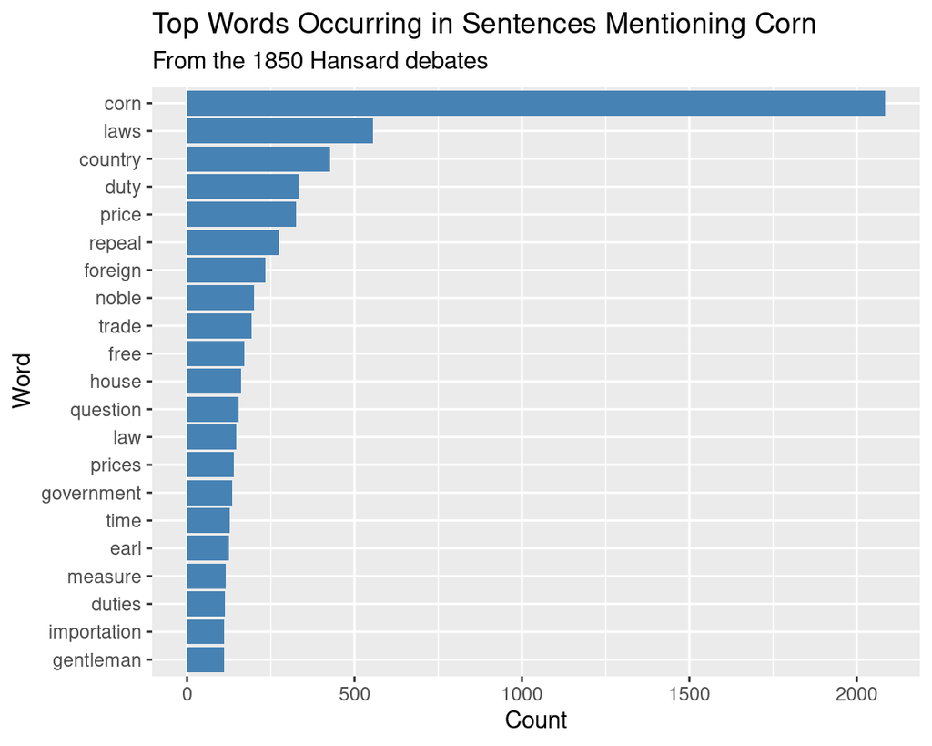

Top words in sentences mentioning corn (Hansard, 1850)

```r
# Keep the 20 most frequent words
# - top_n() selects the words with the highest counts
top_corn <- corn_context %>%
  top_n(20) # Keep the 20 most frequent words

# Visualize the most common words in corn-related speeches
# - reorder() sorts the bars by word count
# - geom_col() creates a bar chart
# - coord_flip() makes the word labels easier to read
# - labs() adds the title and axis labels
ggplot(data = top_corn) +
  geom_col(aes(x = reorder(word, n), # Order words by frequency
               y = n), # Plot word counts on the y-axis
           fill = "steel blue") + # Color the bars
  coord_flip() + # Flip the axes
  labs(title = "Top Words Occurring in Sentences Mentioning Corn", # Add a chart title
       subtitle = "From the 1850 Hansard debates", # Add a subtitle
       x = "Word", # Label the x-axis
       y = "Count") # Label the y-axis
```

Discussions of coal and corn (the grain trade) both exhibit common references to taxation, duties, and time. But gaining insight about these discussions requires us to look more carefully at what separates the two discourses. “Coal” is bound up with the word “public” to a greater degree than “corn,” an intriguing fact. Historian Fredrik Jonsson reminds us that coal early became a sacred calf to members of parliament as the increasing popularity of heating, even by very poor families, made it became anathema for politicians to threaten to tax coal. We see that discussions of coal strongly represent allusions to vessels and mines. That’s because coal required a completely separate infrastructure from other forms of commerce. Coal was heavy enough that it had to be shipped on boats on canals. The canals and railroads had to reach to the remote regions where coal was located. We can see that this infrastructural dimension defines the discussion of coal as distinct from that around the grain trade. Grain could be shipped via wagon, rail, or canal. It could be grown anywhere. It therefore required much less by way of a parliamentary discussion of the oddities of sustaining coal. As Jonsson explains, understanding the public and infrastructural dimensions of coal is crucial, because the large-scale collective investments subsidized by parliament explain how fossil fuels became a “ratchet” – that is, how once they were adopted it was almost impossible to step back from them, even though contemporaries understood many of the problems that a fossil-fuel economy would pose to health.

Further research would be necessary for an analyst to decide whether comparing these two commodities as keywords is worthwhile, and which collocates offer insight. Nevertheless, at this point we have demonstrated a preliminary process with which most of the analyses in this book will start: by loading data, inspecting data, breaking that data into words, and counting those words. Later chapters will complicate this process, giving us more sophisticated approaches to understanding historical change and change over time.

This foundational workflow, loading, inspecting, tokenizing, and counting words, lays the groundwork for more nuanced textual inquiries. One such method, which begins to address the limitations of mere frequency counts, is the “Keywords in Context” (KWIC) approach.